# Prediction Model - Exercise Manner

### Analysis

Different prediction models will be used for analysis purpose.

**Regression Tree**

Fit a tree to these data, and summarize and plot it. First, use the ‘tree’ package as it is much faster than ‘caret’ package.

```r
suppressWarnings(suppressMessages(library(tree)))
set.seed(12345)
tree.training=tree(classe~.,data=training)
summary(tree.training)
```

```
##
## Classification tree:
## tree(formula = classe ~ ., data = training)
## Variables actually used in tree construction:
##  [1] "pitch_forearm"     "magnet_belt_y"     "accel_forearm_z"
##  [4] "magnet_dumbbell_y" "roll_forearm"      "magnet_dumbbell_z"
##  [7] "accel_dumbbell_y"  "pitch_belt"        "yaw_belt"
## [10] "accel_forearm_x"   "yaw_dumbbell"      "magnet_forearm_y"
## [13] "magnet_arm_x"      "accel_dumbbell_z"  "gyros_belt_z"
## Number of terminal nodes:  21
## Residual mean deviance:  1.645 = 22560 / 13720
## Misclassification error rate: 0.3194 = 4388 / 13737
```

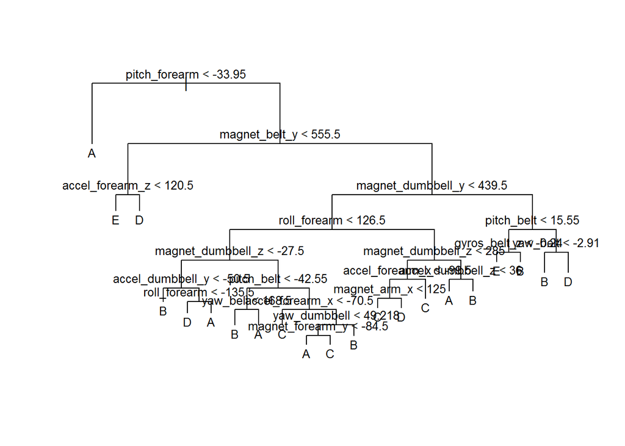

```r
plot(tree.training)
text(tree.training,pretty=0, cex =.8)
```

This is a bushy tree, next is to prune it.

**Rpart Model**

```r
#To prevent e1071 package error, install.packages('e1071', dependencies=TRUE)
modFit <- train(classe ~ .,method="rpart",data=training)
print(modFit$finalModel)
```

```
## n= 13737
##
## node), split, n, loss, yval, (yprob)
##       * denotes terminal node
##
##  1) root 13737 9831 A (0.28 0.19 0.17 0.16 0.18)
##    2) pitch_forearm< -33.15 1123   13 A (0.99 0.012 0 0 0) *
##    3) pitch_forearm>=-33.15 12614 9818 A (0.22 0.21 0.19 0.18 0.2)
##      6) magnet_belt_y>=555.5 11597 8802 A (0.24 0.23 0.21 0.18 0.15)
##       12) magnet_dumbbell_y< 439.5 9683 6945 A (0.28 0.18 0.24 0.17 0.13)
##         24) roll_forearm< 123.5 6101 3635 A (0.4 0.18 0.18 0.14 0.091) *
##         25) roll_forearm>=123.5 3582 2376 C (0.076 0.18 0.34 0.22 0.19)
##           50) accel_forearm_x>=-119.5 2680 1671 C (0.085 0.21 0.38 0.1 0.22) *
##           51) accel_forearm_x< -119.5 902  379 D (0.048 0.073 0.22 0.58 0.081) *
##       13) magnet_dumbbell_y>=439.5 1914 1006 B (0.03 0.47 0.039 0.21 0.25) *
##      7) magnet_belt_y< 555.5 1017  190 E (0.00098 0.002 0.002 0.18 0.81) *
```

To generate prettier plots RPart decision tree plotter,

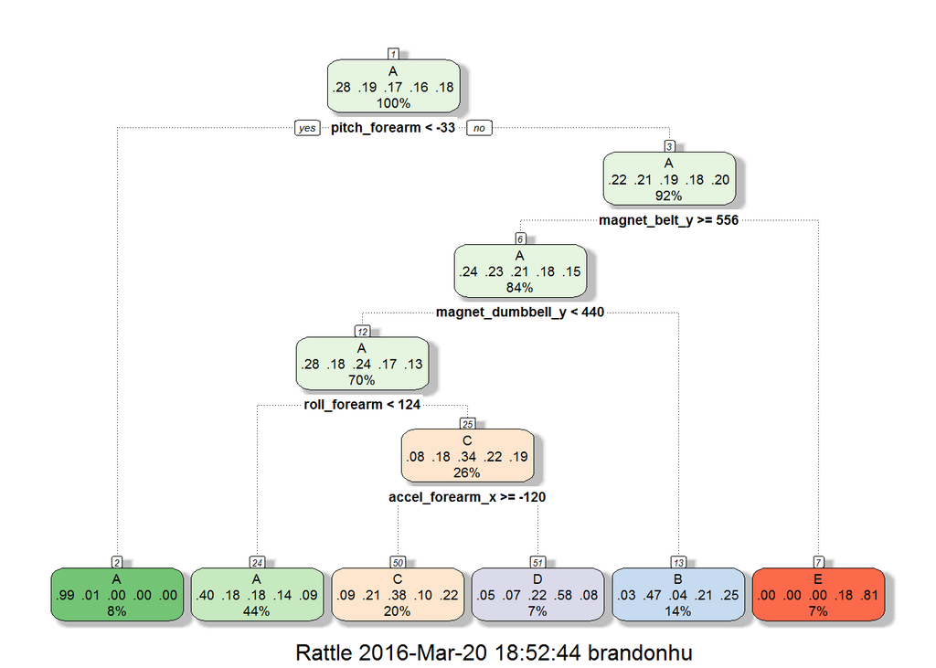

```r
#install.packages('rattle') from R and RTK2 from R
suppressWarnings(suppressMessages(library(rattle)))
fancyRpartPlot(modFit$finalModel)
```

The result from ‘caret’ ‘rpart’ package is close to ‘tree’ package.

### Cross Validation

Perform cross validation to check the performance of the tree on the testing data.

```r
tree.pred=predict(tree.training,testing,type="class")
predMatrix = with(testing,table(tree.pred,classe))
sum(diag(predMatrix))/sum(as.vector(predMatrix)) # error rate
```

```
## [1] 0.6730671
```

The 0.70 is not very accurate.

```r
tree.pred=predict(modFit,testing)
predMatrix = with(testing,table(tree.pred,classe))
sum(diag(predMatrix))/sum(as.vector(predMatrix)) # error rate
```

```
## [1] 0.4917587
```

The 0.50 from ‘caret’ package is much lower than the result from ‘tree’ package.

### Pruning tree

This tree was grown to full depth, and might be too variable. Use Cross Validation to prune it.

```r
cv.training=cv.tree(tree.training,FUN=prune.misclass)
cv.training
```

```
## $size
##  [1] 21 20 18 17 16 15 14 13 10  7  5  1
##
## $dev
##  [1] 4578 4650 4751 5117 5148 5264 5276 5442 6231 6773 7240 9831
##
## $k
##  [1]     -Inf  65.0000 111.0000 132.0000 134.0000 148.0000 150.0000
##  [8] 170.0000 196.3333 231.0000 269.0000 650.5000
##
## $method
## [1] "misclass"
##
## attr(,"class")
## [1] "prune"         "tree.sequence"
```

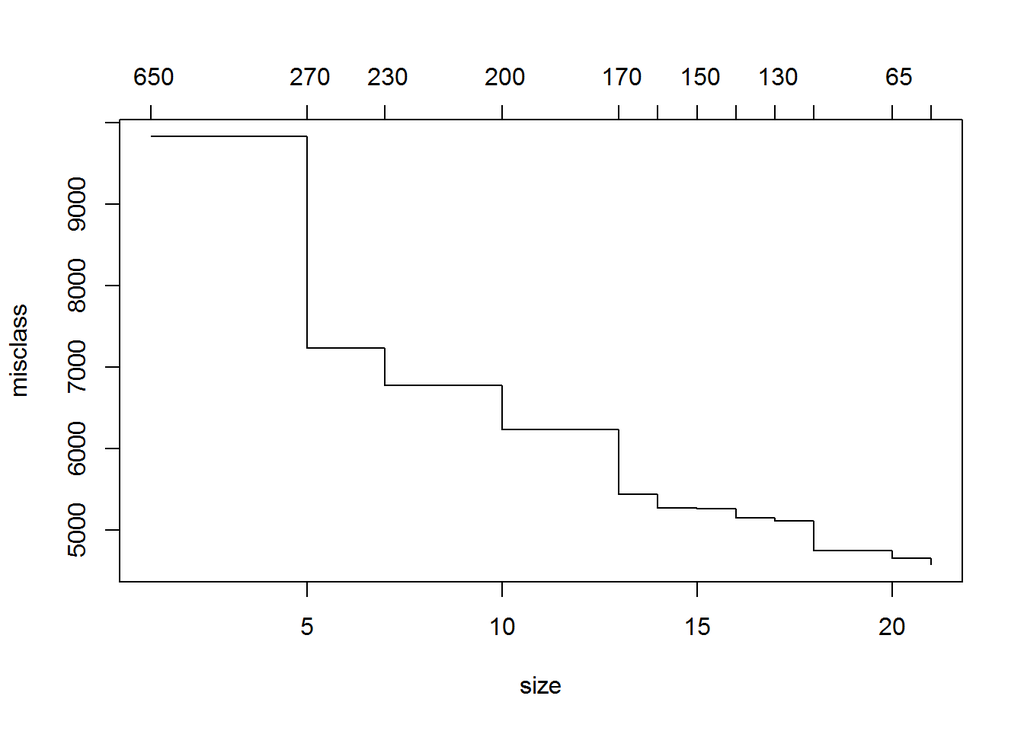

```r
plot(cv.training)
```

It shows that when the size of the tree goes down, the deviance goes up. It means the 21 is a good size (i.e. number of terminal nodes) for this tree so do not need to prune it.

Suppose we prune it at size of nodes at 18.

```r
prune.training=prune.misclass(tree.training,best=18)
```

Now lets evaluate this pruned tree on the test data.

```r
tree.pred=predict(prune.training,testing,type="class")
predMatrix = with(testing,table(tree.pred,classe))
sum(diag(predMatrix))/sum(as.vector(predMatrix)) # error rate
```

```
## [1] 0.6542056
```

0.66 is a little less than 0.70, so pruning did not affect much with repect to misclassification errors, and produce a simpler tree with less predictors to get almost the same result. By pruning, a shallower tree is generated and is easier to interpret.

The single tree is not good enough, so use bootstrap to improve the accuracy by using random forests.

**Random Forests** Random forests build lots of bushy trees, and then average them to reduce the variance.

```r
require(randomForest)
set.seed(12345)
```

Lets fit a random forest and see how well it performs.

```r
rf.training=randomForest(classe~.,data=training,ntree=100, importance=TRUE)
rf.training
```

```
##
## Call:
##  randomForest(formula = classe ~ ., data = training, ntree = 100,      importance = TRUE)
##                Type of random forest: classification
##                      Number of trees: 100
## No. of variables tried at each split: 6
##
##         OOB estimate of  error rate: 0.68%
## Confusion matrix:
##      A    B    C    D    E class.error
## A 3899    5    0    1    1 0.001792115
## B   19 2634    5    0    0 0.009029345
## C    0   19 2372    5    0 0.010016694
## D    0    0   26 2222    4 0.013321492
## E    0    0    3    6 2516 0.003564356
```

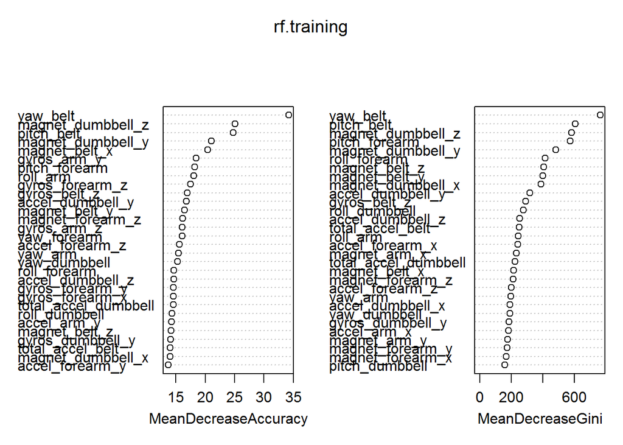

```r
varImpPlot(rf.training)
```

As a result able to see which variables have higher impact on the prediction.

### Out-of Sample Accuracy

Now lets evaluate this tree on the test data.

```r
tree.pred=predict(rf.training,testing,type="class")
predMatrix = with(testing,table(tree.pred,classe))
sum(diag(predMatrix))/sum(as.vector(predMatrix)) # error rate
```

```
## [1] 0.9959218
```

0.99 means we got a very accurate estimate.

No. of variables tried at each split: 6. It means every time, only randomly use 6 predictors to grow the tree. Since p = 43, means can have it from 1 to 43, but it seems 6 is enough to get the good result.

### Conclusion

Since random forest gives a good prediction, it will be used to prediction model for this assignment.

```r
answers <- predict(rf.training, testingData)
answers
```

[output not shown]

[output cut: 3218 more lines]

[output not shown]